# APIs and urban data

Emmanouil Tranos University of Bristol, Alan Turing Institute e.tranos@bristol.ac.uk, [@EmmanouilTranos](https://twitter.com/EmmanouilTranos), [etranos.info](https://etranos.info/)

2022-08-19

## Aims of the practical

- Understand the technicalities and the breadth of the urban data landscape
- Understand the *messiness* of real world (urban) data
- Access programmatically urban data and understand the benefits of such data access practise.

## APIs

Application Programming Interface (APIs) represent a ‘gate’ or otherwise a platform that enables a client (that is you) to interact with a server (for example [opendata.bristol.gov.uk](https://opendata.bristol.gov.uk/pages/homepage/). According to AWS (2022):

> In the context of APIs, the word Application refers to any software with a distinct function. Interface can be thought of as a contract of service between two applications. This contract defines how the two communicate with each other using requests and responses. Their API documentation contains information on how developers are to structure those requests and responses.

The client’s software (this might be R for example) sends a request to the server requesting specific data. The response is the data the client asked.

More commonly, the client might be a mobile phone app (e.g. train network status app) and the server is the network operator’s server.

APIs can be private or public types. For more inthe description from AWS (2022) [here](https://aws.amazon.com/what-is/api/#:~:text=API%20stands%20for%20Application%20Programming,other%20using%20requests%20and%20responses.)

## JSON file format

According to the official JSON website (JSON), JSON

> is a lightweight data-interchange format. It is easy for humans to read and write. It is easy for machines to parse and generate. It is based on a subset of the JavaScript Programming Language Standard ECMA-262 3rd Edition - December 1999. JSON is a text format that is completely language independent but uses conventions that are familiar to programmers of the C-family of languages, including C, C++, C#, Java, JavaScript, Perl, Python, and many others. These properties make JSON an ideal data-interchange language.

It adopts a hierarchical structure such as `attribute:value` instead of the fixed structure of tidy data. Following Singleton, Spielman, and Folch (2017), such `attribute:value` pairs might be:

- “mean income”:“50000”
- “internet speed”:“35”
- “jobs”:“15000”

These attributes might be organised hierarchically:

(“city”:“Bristol,”mean income”: “27000”, “internet speed”: “55”, “jobs”:(“2019”:“15000”, “2020”:“14000”)), (“city”:“Newcastle,”mean income”: “25000”, “internet speed”: “45”, “jobs”:(“2019”:“11000”, “2020”:“10000”))

Although this format is more verbose (attribute names are repeated) it is more flexible (not all observations need to have all attributes) (Singleton, Spielman, and Folch 2017)

## Practical example with API

[opendata.bristol.gov.uk](https://opendata.bristol.gov.uk/pages/homepage/) offers a lot of data about Bristol. For this example, let’s try to work with [Jobs by Ward (by industry) in Bristol 2020](https://opendata.bristol.gov.uk/explore/dataset/jobs-by-ward-by-industry-in-bristol-2020/information/?disjunctive.ward). As you can see, this is a small data set with $35$ observations representing Bristol’s $35$ Wards. You can visualise these data with the `Table` tab and even download a `.csv` with these data. To begin with, do both of these things.

Then, go to the `API` tab. Change the `rows` you want to include in you API request from 10, which is the default here to 35, which is the maximum as we already know. Then clink on the `Submit` button and below that you will see a new link. This URL is your API request. If you carefully read the URL from right to left you can easily recognise the fields you saw on the previous screen. The *weird* output on your screen is the data you requested in `JSON` format.

**Question**: Why should you go through all these efforts to build an API request and download the data in `JSON` file format instead of just downloading a `.csv` file?

So, let’s try to access these data programmatically. First, we need to load the relevant `R` packages

```r
library(tidyverse)
library(jsonlite)
```

To access the data, we are going to use the function `fromJSON()` from the `jsonlite` package. Please check the syntax of this function as well as the other function of this package.

```r
dat <- jsonlite::fromJSON("https://opendata.bristol.gov.uk/api/records/1.0/search/?dataset=jobs-by-ward-by-industry-in-bristol-2020&q=&rows=35&facet=ward", flatten = TRUE)
```

We now have an `R` object called `dat`. Let’s try to see how it looks like

```r
typeof(dat)
```

```
## [1] "list"
```

So, this is a list. If you need a reminder for what a list is, see [here](http://adv-r.had.co.nz/Data-structures.html). Now the difficult part. Let’s try to figure out the structure of this `JSON` formated data.

```r
str(dat)
```

```
## List of 4
##  $ nhits       : int 35
##  $ parameters  :List of 6
##   ..$ dataset : chr "jobs-by-ward-by-industry-in-bristol-2020"
##   ..$ rows    : int 35
##   ..$ start   : int 0
##   ..$ facet   : chr "ward"
##   ..$ format  : chr "json"
##   ..$ timezone: chr "UTC"
##  $ records     :'data.frame':    35 obs. of  24 variables:
##   ..$ datasetid                                          : chr [1:35] "jobs-by-ward-by-industry-in-bristol-2020" "jobs-by-ward-by-industry-in-bristol-2020" "jobs-by-ward-by-industry-in-bristol-2020" "jobs-by-ward-by-industry-in-bristol-2020" ...
##   ..$ recordid                                           : chr [1:35] "8f1ee37587a2233922bfa38b048879368059502e" "464799297e1d1af8bb980450d062c7eedb787042" "4cf81b7e8c57fc61c73eb40c4d4556446d20896c" "e034ff06e7c7d67f6f716c41e8ccd940a36d41fd" ...
##   ..$ record_timestamp                                   : chr [1:35] "2021-12-22T11:29:00.712Z" "2021-12-22T11:29:00.712Z" "2021-12-22T11:29:00.712Z" "2021-12-22T11:29:00.712Z" ...
##   ..$ fields.mining_quarrying_utilities                  : int [1:35] 10 0 0 0 0 10 0 30 2250 0 ...
##   ..$ fields.transport_storage_inc_postal                : int [1:35] 20 0 350 15 200 50 100 600 1750 300 ...
##   ..$ fields.accommodation_food_services                 : int [1:35] 100 150 175 800 700 175 400 400 6000 300 ...
##   ..$ fields.public_administration_defence               : int [1:35] 0 0 0 10 50 0 0 400 9000 200 ...
##   ..$ fields.agriculture_forestry_fishing                : int [1:35] 0 0 0 0 0 0 0 0 0 0 ...
##   ..$ fields.business_administration_support_services    : int [1:35] 125 75 1250 1750 450 225 500 450 11000 125 ...
##   ..$ fields.retail                                      : int [1:35] 700 100 200 700 900 75 800 1500 4500 500 ...
##   ..$ fields.property                                    : int [1:35] 10 15 20 450 175 75 200 30 1750 30 ...
##   ..$ fields.health                                      : int [1:35] 150 125 125 450 500 500 2000 900 12000 1500 ...
##   ..$ fields.motor_trades                                : int [1:35] 125 30 300 30 350 20 40 600 200 40 ...
##   ..$ fields.manufacturing                               : int [1:35] 150 25 900 25 400 5 75 500 500 50 ...
##   ..$ fields.information_communication                   : int [1:35] 225 200 400 800 350 175 450 700 10000 50 ...
##   ..$ fields.education                                   : int [1:35] 350 250 400 200 350 175 1000 500 9000 800 ...
##   ..$ fields.ward_code                                   : chr [1:35] "E05010889" "E05010918" "E05010890" "E05010894" ...
##   ..$ fields.financial_insurance                         : int [1:35] 1500 10 10 600 50 10 75 15 8000 35 ...
##   ..$ fields.ward                                        : chr [1:35] "Bishopsworth" "Windmill Hill" "Brislington East" "Clifton Down" ...
##   ..$ fields.period                                      : chr [1:35] "2020" "2020" "2020" "2020" ...
##   ..$ fields.professional_scientific_technical           : int [1:35] 75 125 200 1000 600 250 800 600 22000 125 ...
##   ..$ fields.construction                                : int [1:35] 500 125 500 300 400 100 350 175 1250 125 ...
##   ..$ fields.arts_entertainment_recreation_other_services: int [1:35] 150 75 75 350 500 35 250 125 1750 100 ...
##   ..$ fields.wholesale                                   : int [1:35] 100 20 450 35 400 15 50 150 900 20 ...
##  $ facet_groups:'data.frame':    1 obs. of  2 variables:
##   ..$ name  : chr "ward"
##   ..$ facets:List of 1
##   .. ..$ :'data.frame':  35 obs. of  4 variables:
##   .. .. ..$ name : chr [1:35] "Ashley" "Avonmouth and Lawrence Weston" "Bedminster" "Bishopston and Ashley Down" ...
##   .. .. ..$ count: int [1:35] 1 1 1 1 1 1 1 1 1 1 ...
##   .. .. ..$ state: chr [1:35] "displayed" "displayed" "displayed" "displayed" ...
##   .. .. ..$ path : chr [1:35] "Ashley" "Avonmouth and Lawrence Weston" "Bedminster" "Bishopston and Ashley Down" ...
```

Well, it’s complicated. Looking on the above output of `list()` the object that looks most useful to us is the `dat$records`.

**Question**: Based on the output of `list()`, why do you think is `dat$records` the most useful part of `dat` for us?

```r
head(dat$records)
```

```
##                                  datasetid
## 1 jobs-by-ward-by-industry-in-bristol-2020
## 2 jobs-by-ward-by-industry-in-bristol-2020
## 3 jobs-by-ward-by-industry-in-bristol-2020
## 4 jobs-by-ward-by-industry-in-bristol-2020
## 5 jobs-by-ward-by-industry-in-bristol-2020
## 6 jobs-by-ward-by-industry-in-bristol-2020
##                                   recordid         record_timestamp
## 1 8f1ee37587a2233922bfa38b048879368059502e 2021-12-22T11:29:00.712Z
## 2 464799297e1d1af8bb980450d062c7eedb787042 2021-12-22T11:29:00.712Z
## 3 4cf81b7e8c57fc61c73eb40c4d4556446d20896c 2021-12-22T11:29:00.712Z
## 4 e034ff06e7c7d67f6f716c41e8ccd940a36d41fd 2021-12-22T11:29:00.712Z
## 5 88ce4a95ea29ef24f38ecd46b3a7e021d325991c 2021-12-22T11:29:00.712Z
## 6 0576d71991a12a6102330e89a595d26fcc92fd32 2021-12-22T11:29:00.712Z
##   fields.mining_quarrying_utilities fields.transport_storage_inc_postal
```

[output cut: 62 more lines]

Looking into the above, I can think of the the following necessary data cleaning and wrangling steps:

1. remove the first three columns as they don’t include any useful data
2. remove the string “fields.” from the column names
3. although not necessary, it is common practice for the first columns to contain identification data such as the ward names and codes.

To do all the above, we will use the below functions from the `dplyr` package, which is part of the [`tidyverse` ecosystem](https://www.tidyverse.org/).

```r
dat <- dat$records %>%
  as.data.frame() %>%
  select(-datasetid, -recordid, -record_timestamp) %>% # remove useless columns
  rename_with(~sub("fields.", "", .)) %>%              # ~ introduces a formula here
  relocate(ward, ward_code, period) %>%                # looks better
  glimpse()                                            # a glimpse of the output
```

```
## Rows: 35
## Columns: 21
## $ ward                                         <chr> "Bishopsworth", "Windmill~
## $ ward_code                                    <chr> "E05010889", "E05010918",~
## $ period                                       <chr> "2020", "2020", "2020", "~
## $ mining_quarrying_utilities                   <int> 10, 0, 0, 0, 0, 10, 0, 30~
## $ transport_storage_inc_postal                 <int> 20, 0, 350, 15, 200, 50, ~
## $ accommodation_food_services                  <int> 100, 150, 175, 800, 700, ~
## $ public_administration_defence                <int> 0, 0, 0, 10, 50, 0, 0, 40~
## $ agriculture_forestry_fishing                 <int> 0, 0, 0, 0, 0, 0, 0, 0, 0~
## $ business_administration_support_services     <int> 125, 75, 1250, 1750, 450,~
## $ retail                                       <int> 700, 100, 200, 700, 900, ~
## $ property                                     <int> 10, 15, 20, 450, 175, 75,~
## $ health                                       <int> 150, 125, 125, 450, 500, ~
## $ motor_trades                                 <int> 125, 30, 300, 30, 350, 20~
## $ manufacturing                                <int> 150, 25, 900, 25, 400, 5,~
## $ information_communication                    <int> 225, 200, 400, 800, 350, ~
## $ education                                    <int> 350, 250, 400, 200, 350, ~
## $ financial_insurance                          <int> 1500, 10, 10, 600, 50, 10~
## $ professional_scientific_technical            <int> 75, 125, 200, 1000, 600, ~
## $ construction                                 <int> 500, 125, 500, 300, 400, ~
## $ arts_entertainment_recreation_other_services <int> 150, 75, 75, 350, 500, 35~
## $ wholesale                                    <int> 100, 20, 450, 35, 400, 15~
```

Let’s try now to do some analysis based on these data and create some outputs.

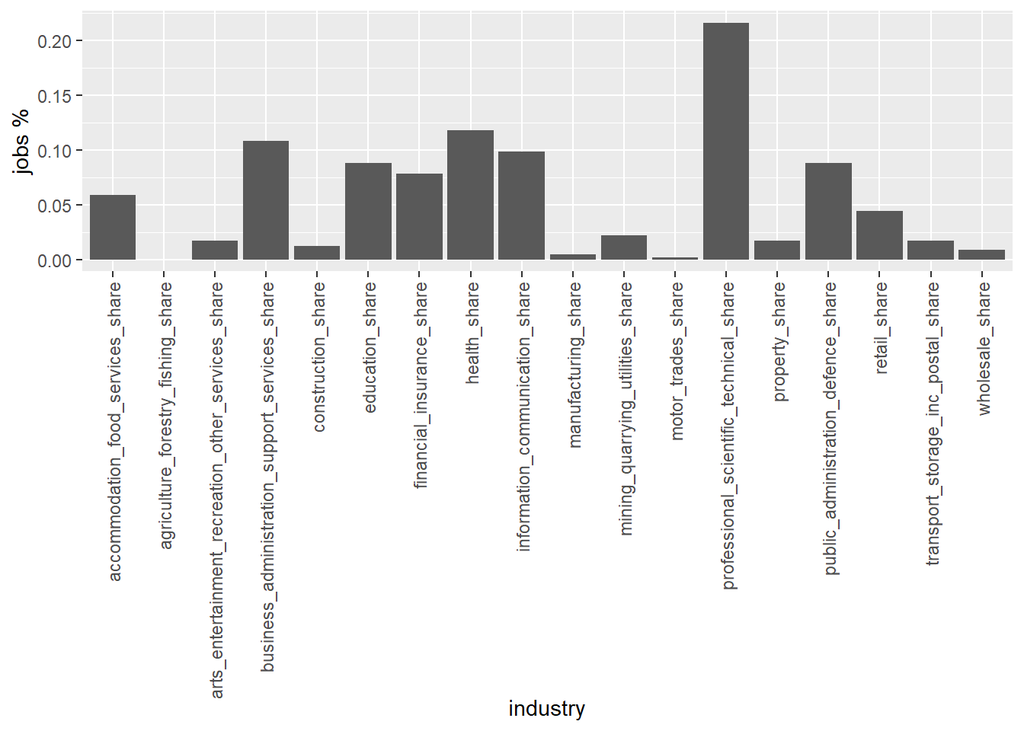

```r
dat %>% mutate(total = rowSums(across(c(4:21))),           # total jobs in a ward
               across(c(4:21),                             # select the columns you are interested in
                      .names = "{col}_share") / total) %>% # divide these columns by total to create industry share within ward
                                                           # and name the new columns as oldname_share
  select(1:2, 23:40) %>%
  pivot_longer(!c(ward, ward_code),                        # These are the columns I am 'pivoting'
               names_to = "industry",                      # This is how I will name the column with all the industries ...
               values_to = "jobs_share") %>%               # ... and the column with the jobs percentage
                                                           # Look https://tidyr.tidyverse.org/articles/pivot.html to
                                                           # understand the long to wide / wide to long transformations.
  # group_by(ward) %>%
  # summarise(total = sum(jobs_share))
  filter(ward == "Central") %>%                            # Let's focus on Central Bristol
  ggplot(aes(x=industry, y=jobs_share)) +                  # ... and create a bar chart for it jobs distribution
    geom_bar(stat = "identity") +
# to understand the "identity part go on the Details section of the geom_bar documentation:
# https://www.rdocumentation.org/packages/ggplot2/versions/1.0.1/topics/geom_bar

    scale_x_discrete(guide = guide_axis(angle = 90)) +     # This line rotates the x labels,
    ylab("jobs %")                                         # and here we rename the y axis.
```

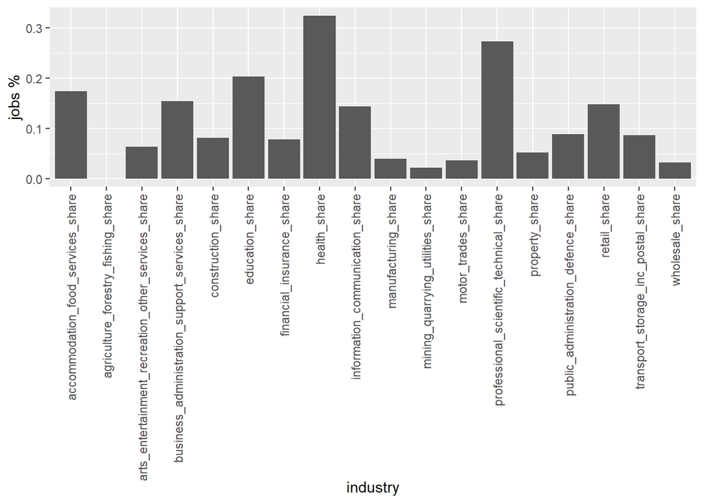

```r
dat %>% mutate(total = rowSums(across(c(4:21))),           # total jobs in a ward
               across(c(4:21),                             # select the columns you are interested in
                      .names = "{col}_share") / total) %>% # divide these columns by total to create industry share within ward
                                                           # and name the new columns as oldname_share
  select(1:2, 23:40) %>%
  pivot_longer(!c(ward, ward_code),                        # These are the columns I am 'pivoting'
               names_to = "industry",                      # This is how I will name the column with all the industries ...
               values_to = "jobs_share") %>%               # ... and the column with the jobs percentage
                                                           # Look https://tidyr.tidyverse.org/articles/pivot.html to
                                                           # understand the long to wide / wide to long transformations.
  # group_by(ward) %>%
  # summarise(total = sum(jobs_share))
  filter(ward == "Central" |
         ward == "Easton") %>%                             # Let's focus on Easton and Central Bristol
  ggplot(aes(x=industry, y=jobs_share)) +                  # ... and create a bar chart for it jobs distribution
    geom_bar(stat = "identity") +
    scale_x_discrete(guide = guide_axis(angle = 90)) +     # This line rotates the x labels,
    ylab("jobs %")                                         # and here we rename the y axis.
```

```r
    facet_wrap(~ward, ncol = 2)                            # facet_wrap creates two graphs based on `ward`
```

[output not shown]

```r
                                                           # and puts one next to each other
```

Well done! You’ve just utilised Bristol’s open data and are part of the urban open data revolution.

Obviously the `x` labels are rather ugly.

**Task:** using and tweaking the code provided here, can you rename these labels?

**Next task:** Search for some other interesting data from [opendata.bristol.gov.uk](https://opendata.bristol.gov.uk/pages/homepage/), access it programmatically, do the necessary data wrangling and produce some graphs in a new `.Rmd` document. Make sure to knit it as `.html`.

If this is to easy for you, why don’t you check the new [Quarto format](https://quarto.org/docs/guide/).

## Accessing APIs using existing `R` packages

Now you might be lucky and somebody else has already done all the infrastructural / backend work in order for you to easily interrogate an API and access their data. How would this look like? Like another `R` package. Here is a list with a few examples:

- `nomisr` is a package that allows you to access [Nomis](https://www.nomisweb.co.uk/) data with `R`. Find [here](https://cran.r-project.org/web/packages/nomisr/vignettes/introduction.html) an introduction.
- `tidysencus` is part of the `tidyverse` ecosystem and offers access to the US Census. This is the [link](https://walker-data.com/tidycensus/). Pay extra attention to the *spatial data* option.
- The city of Toronto offers an `R` [package](https://sharlagelfand.github.io/opendatatoronto/) to access [City of Toronto Open Data Portal](https://open.toronto.ca/).
- See a relevant book by Bauer, Landesvatter, and Behrens (2022) available [here](https://bookdown.org/paul/apis_for_social_scientists/).

**Another task:** On your own time, play with these packages and access some of the (urban) data they offer.

## References

AWS, Amazon. 2022. “What Is an API? - API Beginner’s Guide - AWS — Aws.amazon.com.” https://aws.amazon.com/what-is/api/#:~:text=API%20stands%20for%20Application%20Programming,other%20using%20requests%20and%20responses.

Bauer, P. C., Landesvatter C., and L. Behrens. 2022. “APIs for Social Scientists: A Collaborative Review V1.0.” https://doi.org/https://doi.org/10.5281/zenodo.6798690.

JSON. “JSON — Json.org.” https://www.json.org/json-en.html.

Singleton, Alex D, Seth Spielman, and David Folch. 2017. *Urban Analytics*. Sage.